# Tesla Predictions

Cristian Leo

2023-04-18

## Import Libraries

This R code defines a function load.package() that checks if a specified package is already installed in the R environment. If the package is not installed, it installs it using the install.packages() function and then loads it into the current session using the library() function.

The function takes a single argument, package, which is a character string specifying the name of the package to be loaded.

The code then calls the load.package() function for each of the required packages for the analysis. These packages include dplyr, tidyr, tm, udpipe, SnowballC, vader, ggplot2, ggthemes, stringr, qdapTools, quanteda, quanteda.textstats, quantmod, and tibble.

By using this function, the code ensures that all the required packages are installed and loaded, without having to manually check each package and install it if necessary.

```r
# Check if a package is installed and load it, otherwise install and load it
load.package <- function(package) {
  if (!require(package, character.only = TRUE)) {
    install.packages(package)
    library(package, character.only = TRUE)
  } else {
    library(package, character.only = TRUE)
  }
}

# Load required packages
load.package("dplyr")
load.package("tidyr")
load.package("tm")
load.package("udpipe")
load.package("SnowballC")
load.package("vader")
load.package("ggplot2")
load.package("ggthemes")
load.package("stringr")
load.package("qdapTools")
load.package("quanteda")
load.package("quanteda.textstats")
load.package("quantmod")
load.package("tibble")
load.package("keras")
load.package("tensorflow")
```

## Import Data

Data source: https://www.kaggle.com/datasets/vidyapb/elon-musk-tweets-2015-to-2020

```r
tesla = read.csv("C:/Users/Goldleverse/OneDrive/Desktop/Datasets/elonmusk.csv")
head(tesla, 5)
```

```
##             id conversation_id   created_at       date     time timezone
## 1 1.282940e+18    1.282933e+18 1.594712e+12 2020-07-14 07:28:03      UTC
## 2 1.282845e+18    1.282802e+18 1.594689e+12 2020-07-14 01:10:26      UTC
## 3 1.282806e+18    1.282759e+18 1.594680e+12 2020-07-13 22:34:13      UTC
## 4 1.282800e+18    1.282672e+18 1.594678e+12 2020-07-13 22:12:52      UTC
## 5 1.282800e+18    1.282739e+18 1.594678e+12 2020-07-13 22:12:26      UTC
##    user_id username      name place
## 1 44196397 elonmusk Elon Musk    NA
## 2 44196397 elonmusk Elon Musk    NA
## 3 44196397 elonmusk Elon Musk    NA
## 4 44196397 elonmusk Elon Musk    NA
## 5 44196397 elonmusk Elon Musk    NA
##                                                                                                                                           tweet
## 1                                                                                                                                          Cute
## 2                                                                                                                                           Wow
```

[output cut: 39 more lines]

```r
nrow(tesla)
```

```
## [1] 9286
```

## Data Preparation

### Group by date

This code uses the dplyr package to perform data manipulation operations on the tesla data frame.

%>% group_by(date) groups the rows in the tesla data frame by date, using the %>% operator to pipe the data frame into the group_by() function, which takes one argument: date (the column to group by).

%>% summarize(tweet = paste(tweet, collapse = ” . “)) summarizes the tweet column for each group (i.e., each unique date) by concatenating all the tweets into a single string, separated by a period (.). This is achieved using the %>% operator to pipe the grouped data frame into the summarize() function, which takes one argument: tweet = paste(tweet, collapse =” . “) (a named argument indicating the column to summarize and the operation to apply).

```r
tesla = tesla %>% arrange("date", ascending=F) %>%
  group_by(date) %>%
  summarize(tweet = paste(tweet, collapse = " . "))
tail(tesla, 5)
```

```
## # A tibble: 5 × 2
##   date       tweet
##   <chr>      <chr>
## 1 2020-07-10 "I spoke with Korolev’s family today.\nHe was one of the very best…
## 2 2020-07-11 "Haha . Maybe he should design flag of Mars . 48 65 78 20 74 6f 20…
## 3 2020-07-12 "Thanks :) . That is the near-term danger of AI . I didn’t mind DA…
## 4 2020-07-13 "Reusability is essential. A rocket that is single use is just as …
## 5 2020-07-14 "Cute . Wow"
```

## Create Corpus

This R code creates a corpus object, which is a collection of documents (in this case, tweets about Tesla) that will be used for text analysis.

The Corpus() function is from the tm package, and is used to create a corpus object from a source text (in this case, VectorSource(tesla$tweet)). The VectorSource() function is used to create a source vector from the tweet column of the tesla data frame, which contains the text of the tweets.

```r
corpus = Corpus(VectorSource(tesla$tweet))
corpus[[1]][1]
```

```
## $content
## [1] "If you are curious about the P85D, you can schedule a test drive here: http://ts.la/dE "
```

## Convert to lower case

This R code is using the tm_map() function from the tm package to transform the text in a corpus to lowercase.

```r
# Convert to lower case
corpus = tm_map(corpus, FUN = content_transformer(tolower))
corpus[[1]][1]
```

```
## $content
## [1] "if you are curious about the p85d, you can schedule a test drive here: http://ts.la/de "
```

## Remove URL

The content_transformer() function is being used to apply a regular expression pattern to each document in the corpus. The regular expression pattern is ’http[[:alnum:][:punct:]]*‘, which matches any sequence of characters that starts with ’http’, followed by any combination of alphanumeric and punctuation characters. This pattern is being replaced with a space character using the gsub() function, which is a built-in R function for replacing text in a string.

The overall effect of this code is to remove any URLs or web links from the text documents in the corpus, replacing them with a space character.

```r
# Remover URL
corpus = tm_map(corpus,
                FUN = content_transformer(FUN = function(x)gsub(pattern = 'http[[:alnum:][:punct:]]*',
                                                                replacement = ' ',x = x)))
```

## Remove punctuation

removePunctuation is a built-in function in the tm package that removes all punctuation marks from the text.

```r
# Remove punctuation
corpus = tm_map(corpus,FUN = removePunctuation)
corpus[[1]][1]
```

```
## $content
## [1] "if you are curious about the p85d you can schedule a test drive here   "
```

## Remove StopWords

The removeWords() function is applied to corpus using tm_map(). The removeWords() function is a text preprocessing function that takes a corpus as input and removes specified words from the text. In this case, stopwords(‘english’) is used to generate a list of English stop words that are commonly used but do not carry much meaning on their own (such as “the”, “and”, “a”, etc.). These stop words are then removed from the text in corpus.

The resulting corpus object will have the English stop words removed from its text.

```r
corpus = tm_map(corpus,FUN = removeWords,c(stopwords('english')))
corpus[[1]][1]
```

```
## $content
## [1] "   curious   p85d  can schedule  test drive    "
```

## Strip whitespaces

the stripWhitespace function is being passed as an argument to tm_map(). This function removes extra whitespace (i.e., spaces, tabs, line breaks) from the text in the corpus. The stripWhitespace function is a built-in function in the tm package.

By applying this function to the corpus variable, any extra whitespace will be removed from each document in the corpus.

```r
corpus = tm_map(corpus,FUN = stripWhitespace)
corpus[[1]][1]
```

```
## $content
## [1] " curious p85d can schedule test drive  "
```

## Lemmatization

Lemmatization is the process of reducing a word to its base or dictionary form, which can help to standardize text and improve the accuracy of text analysis.

The code first downloads a pre-trained language model for English using the udpipe_download_model function, and then loads the model using udpipe_load_model.

Next, the code defines a function called lemmatize_document which takes a single document as input and returns a vector of lemmas. The function tokenizes the document using the udpipe_annotate function, extracts the lemma column from the resulting data frame using as.data.frame, and removes numbers, punctuation, and other special characters from the lemmas using the gsub function.

Finally, the code applies the lemmatize_document function to each document in the corpus using the lapply function and stores the result in lemmatized_corpus. The resulting corpus is then printed using head.

```r
# download the model to perform the lemmatization
model <- udpipe_download_model(language = "english")

# load the model
ud_model <- udpipe_load_model(file = model$file_model)

# create a function to lemmatize a single document
lemmatize_document <- function(document) {
  # tokenize the document
  tokens <- udpipe_annotate(ud_model, x = document)

  # extract the lemma column from the tokens
  lemmas <- as.data.frame(tokens)$lemma

  # remove numbers, punctuation and other special characters
  lemmas <- gsub("[^[:alpha:][:space:]]*", "", lemmas)

  # return the lemmatized document
  return(lemmas)
}

# apply lemmatization to each document in the corpus
lemmatized_corpus <- lapply(corpus, lemmatize_document)

# print the lemmatized corpus
head(lemmatized_corpus, 5)
```

```
## [[1]]
## [1] "curious"  "p"        "would"    "can"      "schedule" "test"     "drive"
##
## [[2]]
##  [1] "prob"        "good"        "though"      "give"        "we"
##  [6] "time"        "replace"     "st"          "stage"       "video"
## [11] "transmitter" "need"        "launch"      "nice"        "air"
## [16] "force"       "track"       "radar"       "go"          "launch"
## [21] "postponed"   "time"        "tomorrow"    "rocket"      "reentry"
## [26] "much"        "tougher"     "time"        "around"      "due"
## [31] "deep"        "space"       "mission"     "almost"      ""
## [36] "x"           "force"       ""            "x"           "heat"
## [41] "plenty"      "hydraulic"   "fluid"       "tho"         "launch"
## [46] "st"          "deep"        "space"       "mission"     "today"
## [51] "head"        "earthsun"    "l"           "gravity"     "null"
```

[output cut: 42 more lines]

## Removing non-alpha characters

This code removes non-alpha characters from a previously stemmed corpus of text using the gsub function in R. The purpose of this step is to clean the text further and remove any remaining non-alphabetic characters that may interfere with subsequent text analysis.

The code first defines a function called clean_document which takes a single document as input and returns a cleaned version of the document. The function uses gsub to remove all characters that are not alphabets or white spaces from the document, with the regular expression “[^[:alpha:][:space:]]*” matching any character that is not a letter or whitespace.

Next, the code applies the clean_document function to each document in the previously stemmed corpus using the lapply function and stores the result in cleaned_corpus.

```r
# Removing non-alpha characters
# create a function to remove non-alpha characters from a document
clean_document <- function(document) {
  # remove all characters that are not alphabets or white spaces
  clean_doc <- gsub("[^[:alpha:][:space:]]*", "", document)

  # return the cleaned document
  return(clean_doc)
}

# apply cleaning to each document in the lemmatized or stemmed corpus
cleaned_corpus <- lapply(lemmatized_corpus, clean_document)

# print the cleaned corpus
head(cleaned_corpus, 5)
```

```
## [[1]]
## [1] "curious"  "p"        "would"    "can"      "schedule" "test"     "drive"
##
## [[2]]
##  [1] "prob"        "good"        "though"      "give"        "we"
##  [6] "time"        "replace"     "st"          "stage"       "video"
## [11] "transmitter" "need"        "launch"      "nice"        "air"
## [16] "force"       "track"       "radar"       "go"          "launch"
## [21] "postponed"   "time"        "tomorrow"    "rocket"      "reentry"
## [26] "much"        "tougher"     "time"        "around"      "due"
## [31] "deep"        "space"       "mission"     "almost"      ""
## [36] "x"           "force"       ""            "x"           "heat"
## [41] "plenty"      "hydraulic"   "fluid"       "tho"         "launch"
## [46] "st"          "deep"        "space"       "mission"     "today"
## [51] "head"        "earthsun"    "l"           "gravity"     "null"
```

[output cut: 42 more lines]

# Vectorization

Next, the code removes sparse terms from the DTM using the removeSparseTerms function, which removes terms that appear in fewer than 5% of the documents. The resulting DTM is converted to a matrix and then to a data frame using the as.matrix and as.data.frame functions, respectively.

```r
# TF-IDF
dtm_tfidf = DocumentTermMatrix(x=cleaned_corpus,
                               control = list(normalize=TRUE))

xdtm_tfidf = removeSparseTerms(dtm_tfidf,sparse = 0.95)
xdtm_tfidf = as.data.frame(as.matrix(xdtm_tfidf))
sort(colSums(xdtm_tfidf),decreasing = T)
```

```
##           "",      "tesla",          "s",        "not",        "car",
##          4172           802           615           601           452
##         "be",         "do",       "just",        "yes",       "make",
##           405           391           377           376           365
##           "")       "good",       "need",        "can",       "like",
##           356           331           322           315           307
##       "year",      "model",       "work",         "go",        "get",
##           301           299           298           292           287
##       "time",      "great",       "much",        "one",         "re",
##           257           252           238           231           227
##       "come",        "use",       "next",     "spacex",       "high",
##           220           212           204           201           197
##       "also",     "people",       "true",        "now",       "soon",
##           188           186           183           174           174
##     "rocket",       "even",       "team",       "take",     "better",
##           170           169           169           165           164
##       "yeah",      "think",       "look", "production",      "right",
##           163           162           159           159           158
##       "sure",      "first",   "probably",      "month",     "engine",
##           158           157           157           152           152
##    "exactly",       "many",         "we",        "new",        "say",
##           152           151           149           148           148
##   "starship",       "week",        "day",     "launch",     "thanks",
##           148           147           146           145           143
##        "way",   "actually",       "test",      "maybe",        "see",
##           142           139           138           137           132
##       "love",      "point",        "lot",     "falcon",       "know",
##           132           130           130           130           127
##    "company",      "still",     "change",     "design",      "thing",
##           122           121           118           117           115
##     "almost",          "x",     "really",       "best",       "want",
##           114           114           114           112           112
##      "drive",       "cost",        "mar",      "super",       "hard",
##           110           108           107           105           104
##   "software",      "build",  "autopilot",      "start",      "order",
##           104           103           103           102           100
##       "full",      "heavy",     "system",       "mean",      "power",
##            99            98            96            95            95
##          "m",       "back",     "flight",      "earth",       "part",
##            94            94            93            93            93
##        "try",         "ok",       "haha",    "landing",       "cool",
##            92            92            91            89            89
##      "sound",       "long",        "end",       "give",     "future",
##            88            87            87            86            85
##        "add",       "less",  "hopefully",        "big",       "real",
##            85            84            83            83            82
##       "well", "definitely",    "improve",     "pretty",      "today",
##            80            80            80            80            75
```

```r
head(xdtm_tfidf, 10)
```

```
##    "can", "test", "", "almost", "give", "go", "good", "launch", "m", "much",
## 1       1       1   0         0       0     0       0         0    0       0
## 2       0       0   4         1       1     1       1         3    1       1
## 3       0       0   2         0       0     0       0         0    0       0
## 4       0       0   2         0       1     0       3         1    1       0
## 5       0       0   0         0       0     0       0         0    0       0
## 6       0       0   0         0       0     0       0         0    0       0
## 7       0       0   0         0       0     0       0         0    0       0
## 8       0       0   2         0       0     0       0         1    0       0
## 9       0       0   1         0       0     0       0         0    0       0
## 10      1       0   0         0       0     0       0         0    0       0
##    "need", "point", "rocket", "time", "today", "we", "x", "") "change", "high",
## 1        0        0         0       0        0     0    0   0         0       0
## 2        1        1         1       3        1     1    3   0         0       0
## 3        0        0         0       0        0     0    0   1         1       1
```

[output cut: 139 more lines]

## Merging datasets

```r
tesla_tfidf = cbind(tesla, xdtm_tfidf)
head(tesla_tfidf, 3)
```

```
##         date
## 1 2015-01-30
## 2 2015-02-08
## 3 2015-02-10
##                                                                                                                                                                                                                                                                                                          …
## 1                                                                                                                                                                                                                                                                                                        …
## 2 Prob good though. Will give us time to replace 1st stage video transmitter (not needed for launch, but nice to have). . Air Force tracking radar went down. Launch postponed to same time tomorrow. . Rocket reentry will be much tougher this time around due to deep space mission. Almost 2X force a…
## 3                                                                                                                                                      Launch postponed to tomorrow due to high winds at the Cape, but Dragon still inbound from orbit in 90 mins . Extreme wind shear over Cape Canavera…
##   "can", "test", "", "almost", "give", "go", "good", "launch", "m", "much",
## 1      1       1   0         0       0     0       0         0    0       0
## 2      0       0   4         1       1     1       1         3    1       1
## 3      0       0   2         0       0     0       0         0    0       0
##   "need", "point", "rocket", "time", "today", "we", "x", "") "change", "high",
## 1       0        0         0       0        0     0    0   0         0       0
## 2       1        1         1       3        1     1    3   0         0       0
```

[output cut: 49 more lines]

# Sentiment Analysis

This code performs sentiment analysis on a collection of tweets related to Tesla using the VADER (Valence Aware Dictionary and sEntiment Reasoner) sentiment analysis tool. The code loops through each tweet in the “tesla” data frame and applies the get_vader function to extract the sentiment scores.

The sentiment scores are then appended to empty lists for each score type, including “word_scores”, “compound”, “pos”, “neu”, “neg”, and “but_count”. The length() function is used to determine the index of the next available spot in each list.

After processing all tweets, the code combines the lists into a data frame named vader_df using the data.frame() function. The unlist() function is used to flatten the lists into a single vector for each score type. The resulting data frame contains one row per tweet and columns for each score type.

```r
# Create empty lists
word_scores_list = list()
compound_list = list()
pos_list = list()
neu_list = list()
neg_list = list()
but_count_list = list()

# Loop through tweets
for (row in tesla$tweet) {
  # Get sentiment scores
  sentiment = get_vader(row, incl_nt = T, neu_set = T, rm_qm = T)

  # Append scores to lists
  word_scores_list[[length(word_scores_list) + 1]] = sentiment["word_scores"]
  compound_list[[length(compound_list) + 1]] = sentiment["compound"]
  pos_list[[length(pos_list) + 1]] = sentiment["pos"]
  neu_list[[length(neu_list) + 1]] = sentiment["neu"]
  neg_list[[length(neg_list) + 1]] = sentiment["neg"]
  but_count_list[[length(but_count_list) + 1]] = sentiment["but_count"]
}

# Combine lists into data frame
vader_df = data.frame(
  word_scores = unlist(word_scores_list),
  compound = unlist(compound_list),
  pos = unlist(pos_list),
  neu = unlist(neu_list),
  neg = unlist(neg_list),
  but_count = unlist(but_count_list)
)

colnames(vader_df)
```

```
## [1] "word_scores" "compound"    "pos"         "neu"         "neg"
## [6] "but_count"
```

## Merging Data

```r
tesla_sentiment = cbind(tesla_tfidf, vader_df)
print(nrow(tesla_sentiment))
```

```
## [1] 1360
```

```r
head(tesla_sentiment, 5)
```

```
##         date
## 1 2015-01-30
## 2 2015-02-08
## 3 2015-02-10
## 4 2015-02-11
## 5 2015-02-12
##                                                                                                                                                                                                                                                                                                          …
## 1                                                                                                                                                                                                                                                                                                        …
## 2                                                                                                                                                                                                                                                                                                        …
## 3                                                                                                                                                                                                                                                                                                        …
## 4 Rocket soft landed in the ocean within 10m of target & nicely vertical! High probability of good droneship landing in non-stormy weather. . Primary mission on target. Spacecraft head towards the sun! All good there. . @DanielLockyer We could actually do that...maybe we should . Planning a signi…
## 5                                                                                                                                                                                                                                                                                                        …
##   "can", "test", "", "almost", "give", "go", "good", "launch", "m", "much",
## 1      1       1   0         0       0     0       0         0    0       0
## 2      0       0   4         1       1     1       1         3    1       1
```

[output cut: 93 more lines]

## Export dataset

```r
write.csv(tesla_sentiment, 'pre_finance.csv')
```

## Import Stock Data

This code is for downloading stock price data for Tesla from Yahoo Finance within a specified date range.

First, the stock symbol “TSLA” is defined and the start and end dates are specified using as.Date().

getSymbols() is then used to download the historical stock price data for TSLA from Yahoo Finance, with the data source specified as “yahoo” and the date range specified using the from and to arguments.

Next, Ad() is used to extract the adjusted close price data from the downloaded data. as.data.frame() is used to convert the data into a dataframe format, and rownames_to_column() is used to move the date information from the row names to a separate “date” column in the dataframe. The resulting dataframe is assigned to tsla_prices.

```r
# define the stock symbol and data range
symbol <- "TSLA"
start_date <- as.Date("2015-01-29")
end_date <- as.Date("2020-07-15")

# get the stock price data from Yahoo Finance
getSymbols(symbol, src = "yahoo", from = start_date, to = end_date)
```

```
## [1] "TSLA"
```

```r
# extract the adjusted close price data
tsla_prices <- Ad(get(symbol))

tsla_prices <- as.data.frame(tsla_prices) %>%
  rownames_to_column(var = "date")

# view the last 10 prices
tail(tsla_prices)
```

```
##            date TSLA.Adjusted
## 1369 2020-07-07      92.65733
## 1370 2020-07-08      91.05867
## 1371 2020-07-09      92.95200
## 1372 2020-07-10     102.97667
## 1373 2020-07-13      99.80400
## 1374 2020-07-14     101.12000
```

This code converts the “date” column in the tesla_sentiment and tsla_prices dataframes from character or factor type to Date type using as.Date().

This is useful when combining or merging dataframes on the basis of the “date” column, as it ensures that the dates are in the same format and can be compared properly.

```r
tesla_sentiment$date = as.Date(tesla_sentiment$date)
tsla_prices$date = as.Date(tsla_prices$date)
tail(tesla_sentiment, 3)
```

```
##            date
## 1358 2020-07-12
## 1359 2020-07-13
## 1360 2020-07-14
##                                                                                                                                                                                                                                                                                                          …
## 1358                                                                                                                                                                                                                                                                                                     …
## 1359 Reusability is essential. A rocket that is single use is just as absurd as a single use airplane. F9 engines already fire 3 times per flight. . Wild times! . We’re being extra paranoid. Maximizing probability of successful launch is paramount. . Welcome anytime . Well, I do care very much ab…
## 1360                                                                                                                                                                                                                                                                                                     …
##      "can", "test", "", "almost", "give", "go", "good", "launch", "m", "much",
## 1358      0       0   1         0       0     0       0         0    0       0
## 1359      0       1   7         0       0     0       1         1    0       2
## 1360      0       0   0         0       0     0       0         0    0       0
##      "need", "point", "rocket", "time", "today", "we", "x", "") "change",
## 1358       0        0         0       0        0     0    0   0         0
## 1359       0        0         1       2        0     0    1   0         0
```

[output cut: 61 more lines]

## Merge Data

```r
colnames(tesla_sentiment)
```

```
##   [1] "date"            "tweet"           "\"can\","        "\"test\","
##   [5] "\"\","           "\"almost\","     "\"give\","       "\"go\","
##   [9] "\"good\","       "\"launch\","     "\"m\","          "\"much\","
##  [13] "\"need\","       "\"point\","      "\"rocket\","     "\"time\","
##  [17] "\"today\","      "\"we\","         "\"x\","          "\"\")"
##  [21] "\"change\","     "\"high\","       "\"like\","       "\"still\","
##  [25] "\"actually\","   "\"come\","       "\"future\","     "\"landing\","
##  [29] "\"maybe\","      "\"try\","        "\"best\","       "\"car\","
##  [33] "\"model\","      "\"s\","          "\"year\","       "\"flight\","
##  [37] "\"next\","       "\"now\","        "\"one\","        "\"work\","
##  [41] "\"full\","       "\"back\","       "\"be\","         "\"build\","
##  [45] "\"do\","         "\"get\","        "\"mar\","        "\"not\","
##  [49] "\"really\","     "\"see\","        "\"lot\","        "\"soon\","
##  [53] "\"new\","        "\"system\","     "\"company\","    "\"even\","
##  [57] "\"long\","       "\"people\","     "\"think\","      "\"drive\","
```

[output cut: 17 more lines]

This code performs the following tasks:

It merges two data frames, tesla_sentiment and tsla_prices, on the “date” column, using merge() function. The argument all.y=TRUE ensures that all the rows from the tsla_prices data frame are included in the merged data frame.

It adds a new column called “increase” to the merged data frame. This column contains binary values indicating whether the stock price increased or not on a particular day. This will be our target variable.

```r
merged_df = merge(tesla_sentiment, tsla_prices, by="date", all.y = TRUE)

# Add increase column
merged_df$increase <- c(0, ifelse(diff(merged_df$TSLA.Adjusted) > 0, 1, 0))
merged_df[,3:ncol(merged_df)-1][is.na(merged_df[, 3:ncol(merged_df)-1])] = 0
tail(merged_df, 2)
```

[output not shown]

```r
write.csv(merged_df, file="tesla_sentiment.csv", row.names = F)
```

# Exploratory Analysis

```r
tesla_sentiment = read.csv('tesla_sentiment.csv')
head(tesla_sentiment, 2)
```

```
##         date
## 1 2015-01-29
## 2 2015-01-30
##                                                                                     tweet
## 1                                                                                       0
## 2 If you are curious about the P85D, you can schedule a test drive here: http://ts.la/dE
##   X.can.. X.test.. X... X.almost.. X.give.. X.go.. X.good.. X.launch.. X.m..
## 1       0        0    0          0        0      0        0          0     0
## 2       1        1    0          0        0      0        0          0     0
##   X.much.. X.need.. X.point.. X.rocket.. X.time.. X.today.. X.we.. X.x.. X....1
## 1        0        0         0          0        0         0      0     0      0
## 2        0        0         0          0        0         0      0     0      0
##   X.change.. X.high.. X.like.. X.still.. X.actually.. X.come.. X.future..
## 1          0        0        0         0            0        0          0
## 2          0        0        0         0            0        0          0
##   X.landing.. X.maybe.. X.try.. X.best.. X.car.. X.model.. X.s.. X.year..
## 1           0         0       0        0       0         0     0        0
## 2           0         0       0        0       0         0     0        0
##   X.flight.. X.next.. X.now.. X.one.. X.work.. X.full.. X.back.. X.be..
## 1          0        0       0       0        0        0        0      0
## 2          0        0       0       0        0        0        0      0
##   X.build.. X.do.. X.get.. X.mar.. X.not.. X.really.. X.see.. X.lot.. X.soon..
## 1         0      0       0       0       0          0       0       0        0
## 2         0      0       0       0       0          0       0       0        0
##   X.new.. X.system.. X.company.. X.even.. X.long.. X.people.. X.think..
## 1       0          0           0        0        0          0         0
## 2       0          0           0        0        0          0         0
##   X.drive.. X.hopefully.. X.tesla.. X.well.. X.just.. X.spacex.. X.take..
## 1         0             0         0        0        0          0        0
## 2         0             0         0        0        0          0        0
##   X.look.. X.falcon.. X.want.. X.mean.. X.say.. X.design.. X.power.. X.week..
## 1        0          0        0        0       0          0         0        0
## 2        0          0        0        0       0          0         0        0
##   X.thing.. X.many.. X.true.. X.end.. X.less.. X.way.. X.hard.. X.big.. X.ok..
## 1         0        0        0       0        0       0        0       0      0
## 2         0        0        0       0        0       0        0       0      0
##   X.month.. X.day.. X.haha.. X.real.. X.thanks.. X.cool.. X.know.. X.love..
## 1         0       0        0        0          0        0        0        0
## 2         0       0        0        0          0        0        0        0
##   X.also.. X.team.. X.great.. X.first.. X.right.. X.yeah.. X.probably..
## 1        0        0         0         0         0        0            0
## 2        0        0         0         0         0        0            0
##   X.better.. X.re.. X.software.. X.start.. X.yes.. X.cost.. X.definitely..
## 1          0      0            0         0       0        0              0
## 2          0      0            0         0       0        0              0
##   X.production.. X.heavy.. X.use.. X.super.. X.add.. X.autopilot.. X.sure..
## 1              0         0       0         0       0             0        0
## 2              0         0       0         0       0             0        0
##   X.make.. X.improve.. X.sound.. X.engine.. X.earth.. X.order.. X.exactly..
## 1        0           0         0          0         0         0           0
## 2        0           0         0          0         0         0           0
##   X.part.. X.pretty.. X.starship..
## 1        0          0            0
## 2        0          0            0
##                                       word_scores compound   pos   neu neg
## 1                                               0    0.000 0.000 0.000   0
## 2 {0, 0, 0, 1.3, 0, 0, 0, 0, 0, 0, 0, 0, 0, 0, 0}    0.318 0.141 0.859   0
##   but_count TSLA.Adjusted increase
## 1         0      13.68000        0
## 2         0      13.57333        0
```

This code block is for data cleaning, and it is processing a data frame named tesla_sentiment. Here are the details for each line:

The first line uses regular expression to remove ‘X.’ and ‘..’ from the column names of tesla_sentiment and stores the modified column names in a variable called new_col_names. The second line assigns the new column names to the data frame tesla_sentiment using the colnames function. The third line selects all columns from tesla_sentiment that are not equal to ““,”m”, “x”, “.1”, and “s” using the negation operator ! and %in% function, and assigns the resulting data frame to a new variable called final_data_new. The head function is then used to display the first five rows of the cleaned data frame.

```r
# Remove 'X.' and '..' from column names
new_col_names = gsub('X\\.|\\.\\.', '', colnames(tesla_sentiment))
# Assign new column names to the data frame
colnames(tesla_sentiment) <- new_col_names
# Drop columns "", "m", "x", ".1", and "s"
final_data_new <- tesla_sentiment[, !names(tesla_sentiment) %in% c('', 'm', 'x', '.1', 's')]
head(final_data_new, 5)
```

```
##         date
## 1 2015-01-29
## 2 2015-01-30
## 3 2015-02-02
## 4 2015-02-03
## 5 2015-02-04
##                                                                                     tweet
## 1                                                                                       0
## 2 If you are curious about the P85D, you can schedule a test drive here: http://ts.la/dE
## 3                                                                                       0
## 4                                                                                       0
## 5                                                                                       0
##   can test almost give go good launch much need point rocket time today we
## 1   0    0      0    0  0    0      0    0    0     0      0    0     0  0
## 2   1    1      0    0  0    0      0    0    0     0      0    0     0  0
```

[output cut: 63 more lines]

This code creates a histogram visualization of the “increase” column in the “final_data_new” data frame. The “increase” column contains binary values (0 or 1) that represent whether the stock price increased or decreased on a particular day.

The code uses the ggplot2 library to create the histogram. The “data” parameter specifies the data frame to use. The “aes” function specifies the x-axis variable, which is the “increase” column.

The “geom_histogram” function creates the histogram, with the “fill” parameter setting the fill color of the bars.

The “theme_bw” function sets the theme of the plot to a black and white style.

The “xlab” function sets the label for the x-axis.

Finally, the “coord_flip” function is used to flip the x and y axes of the plot. This is done to make the plot horizontal, with the bars running from left to right rather than from bottom to top.

[figure not shown]

```r
#visualizing increase vs decrease
ggplot(data=final_data_new,aes(x=increase))+
  geom_bar(fill=c('orange', 'brown'))+
  theme_bw()+
  xlab('Stock Increase(0) or Decrease(1)') +
coord_flip()
```

```r
final_data_new_visual <- final_data_new[, !names(final_data_new) %in% c('word_scores', 'tweet','date','compound', 'pos', 'neu', 'neg', 'but_count', 'TSLA.Adjusted', 'increase')]
head(final_data_new_visual, 3)
```

```
##   can test almost give go good launch much need point rocket time today we
## 1   0    0      0    0  0    0      0    0    0     0      0    0     0  0
## 2   1    1      0    0  0    0      0    0    0     0      0    0     0  0
## 3   0    0      0    0  0    0      0    0    0     0      0    0     0  0
##   change high like still actually come future landing maybe try best car model
## 1      0    0    0     0        0    0      0       0     0   0    0   0     0
## 2      0    0    0     0        0    0      0       0     0   0    0   0     0
## 3      0    0    0     0        0    0      0       0     0   0    0   0     0
##   year flight next now one work full back be build do get mar not really see
## 1    0      0    0   0   0    0    0    0  0     0  0   0   0   0      0   0
## 2    0      0    0   0   0    0    0    0  0     0  0   0   0   0      0   0
## 3    0      0    0   0   0    0    0    0  0     0  0   0   0   0      0   0
##   lot soon new system company even long people think drive hopefully tesla well
## 1   0    0   0      0       0    0    0      0     0     0         0     0    0
## 2   0    0   0      0       0    0    0      0     0     0         0     0    0
```

[output cut: 21 more lines]

This code visualizes the top 25 words appearing in Elon Musk’s tweets.

col_sums calculates the sum of each column in final_data_new_visual, which contains the frequency of each word used in the tweets.

final_data_new_visual_sums creates a new data frame containing two columns: word and value, where word is the name of the word and value is the sum of its frequency in the tweets.

final_data_new_visual_sums_top25 creates a subset of final_data_new_visual_sums containing only the top 25 words sorted by their frequency in descending order.

Finally, ggplot is used to create a bar plot with the x-axis representing the words and the y-axis representing the sum of their frequency. The reorder function is used to sort the words on the x-axis by their value in descending order. The theme function is used to rotate the x-axis labels by 90 degrees, and coord_flip is used to switch the axes of the plot. The bars are filled with the color “sienna3”.

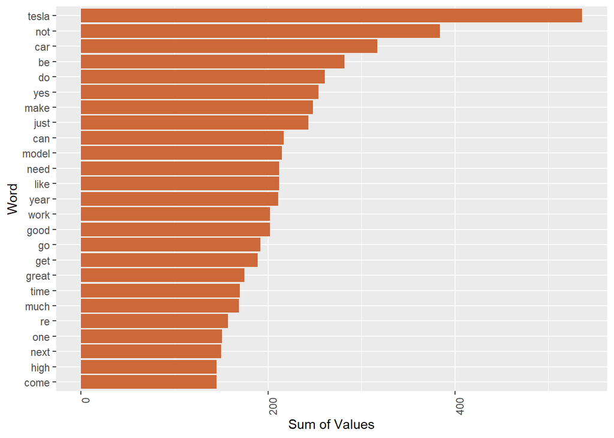

```r
#visualizing top 25 words appearing in Elon's Tweet
col_sums <- colSums(final_data_new_visual)

final_data_new_visual_sums <- data.frame(
  word = names(col_sums),
  value = col_sums
)
final_data_new_visual_sums_top25 <- final_data_new_visual_sums[order(final_data_new_visual_sums$value, decreasing = TRUE),][1:25,]
# visualize the results with a bar plot
ggplot(data = final_data_new_visual_sums_top25, aes(x = reorder(word, value), y = value)) +
  geom_bar(stat = "identity", fill = "sienna3") +
  labs(x = "Word", y = "Sum of Values") +
  theme(axis.text.x = element_text(angle = 90, hjust = 1)) +
  coord_flip()
```

This code performs some date manipulations and summarizes the data on a yearly basis.

The lubridate library is loaded, which provides some useful functions for working with dates. Then, the as.Date() function is used to convert the date column of the final_data_new data frame to a date format. The quarter() and year() functions from lubridate are then used to create new columns quarter and year, which extract the quarter and year information from the date column.

Next, the %>% operator from the dplyr package is used to pipe the final_data_new data frame to a series of operations. The mutate() function creates a new column year, which extracts the year information from the date column. The data is then grouped by year using the group_by() function, and the summarise() function is used to calculate the mean values of the pos, neu, compound, neg, and TSLA.Adjusted columns for each year. The resulting data frame df_yearly contains the summarized data.

```r
library(lubridate)
final_data_new$date <- as.Date(final_data_new$date, format = "%Y-%m-%d")

final_data_new$quarter <- quarter(final_data_new$date)
final_data_new$year <- year(final_data_new$date)

df_yearly <- final_data_new %>%
  mutate(year = year(date)) %>%
  group_by(year) %>%
  summarise(pos = mean(pos), neu = mean(neu), compound = mean(compound), neg = mean(neg), TSLA.Adjusted = mean(TSLA.Adjusted))

head(final_data_new, 5)
```

```
##         date
## 1 2015-01-29
## 2 2015-01-30
## 3 2015-02-02
## 4 2015-02-03
## 5 2015-02-04
##                                                                                     tweet
## 1                                                                                       0
## 2 If you are curious about the P85D, you can schedule a test drive here: http://ts.la/dE
## 3                                                                                       0
## 4                                                                                       0
## 5                                                                                       0
##   can test almost give go good launch much need point rocket time today we
## 1   0    0      0    0  0    0      0    0    0     0      0    0     0  0
## 2   1    1      0    0  0    0      0    0    0     0      0    0     0  0
```

[output cut: 63 more lines]

This code creates two plots side by side, showing the sentiment scores over time and the TSLA adjusted stock prices over time.

The first plot is created using ggplot and shows four lines, each representing a different sentiment score (positive, neutral, compound, and negative) over the years in the dataset. The x-axis represents the year, and the y-axis represents the sentiment score. The color of each line is manually set using scale_color_manual, and the plot is given a title and a y-axis label.

The second plot is also created using ggplot and shows a single line representing the TSLA adjusted stock price over the years in the dataset. The x-axis and y-axis represent the year and the adjusted stock price, respectively. The plot is given a title and a y-axis label.

The two plots are combined side by side using the grid.arrange() function from the gridExtra package. The ncol argument specifies the number of columns in the resulting grid, and the widths argument specifies the relative widths of the columns.

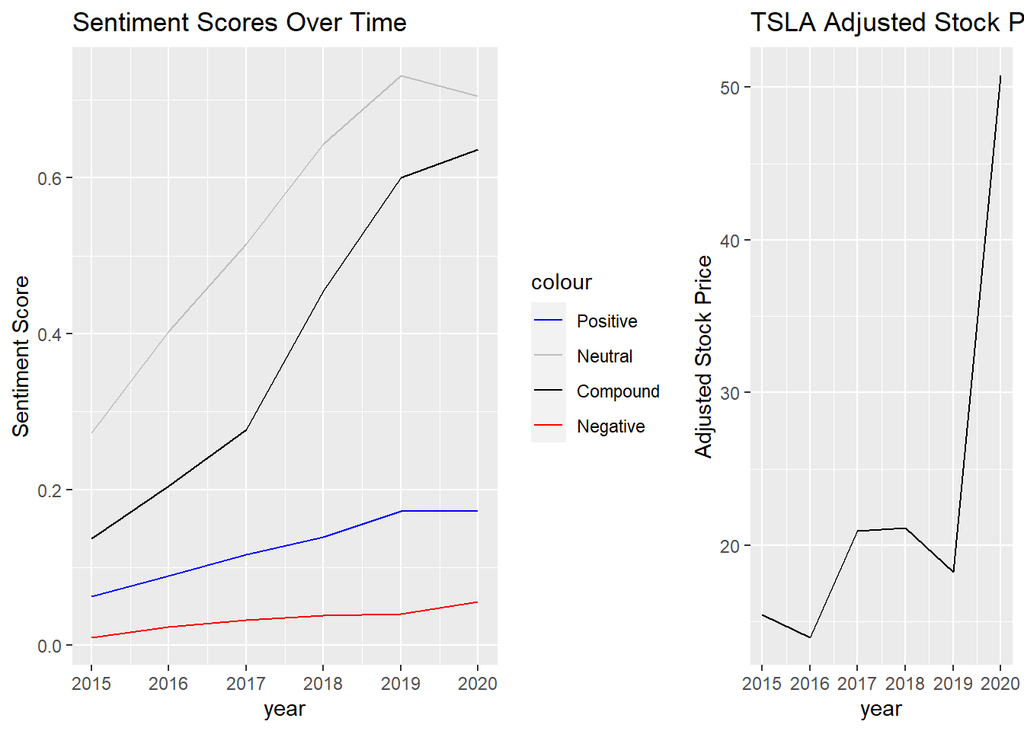

```r
#Sentiment Score over time vs Stock Price
# Create the first plot for sentiment scores
plot1 <- ggplot(data = df_yearly, aes(x = year)) +
         geom_line(aes(y = pos, color = "Positive")) +
         geom_line(aes(y = neu, color = "Neutral")) +
         geom_line(aes(y = compound, color = "Compound")) +
         geom_line(aes(y = neg, color = "Negative")) +
         ylab("Sentiment Score") +
         ggtitle("Sentiment Scores Over Time") +
         scale_color_manual(values = c("Positive" = "blue", "Neutral" = "grey",
                                       "Compound" = "black", "Negative" = "red"))

# Create the second plot for TSLA adjusted stock prices
plot2 <- ggplot(data = df_yearly, aes(x = year)) +
         geom_line(aes(y = TSLA.Adjusted)) +
         ylab("Adjusted Stock Price") +
         ggtitle("TSLA Adjusted Stock Prices Over Time")

# Combine the two plots side by side using grid.arrange() from the gridExtra package
library(gridExtra)
grid.arrange(plot1, plot2, ncol = 2,widths=c(2/3, 1/3))
```

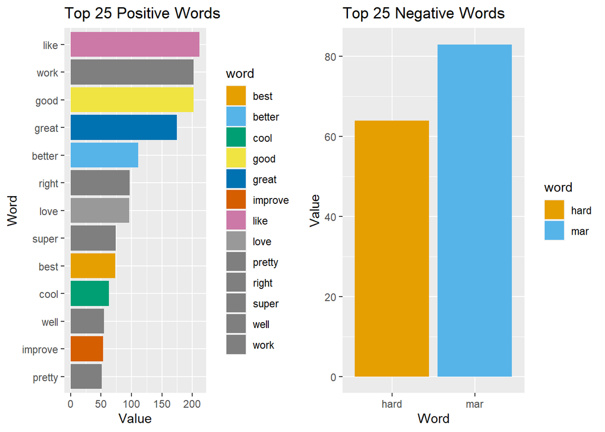

```r
#Visualizing top positive words and top negative words
library(tidytext)
bing <- read.csv("C:/Users/Goldleverse/OneDrive/Desktop/Datasets/bing-2.csv")
bing_sentiment <- final_data_new_visual_sums%>%
  inner_join(bing)%>%
  group_by(sentiment)
# filter to only include positive and negative sentiment
bing_sentiment_pos <- bing_sentiment[bing_sentiment$sentiment == "positive", ]
bing_sentiment_neg <- bing_sentiment[bing_sentiment$sentiment == "negative", ]

# arrange in descending order by value
bing_sentiment_pos <- bing_sentiment_pos[order(-bing_sentiment_pos$value), ]
bing_sentiment_neg <- bing_sentiment_neg[order(-bing_sentiment_neg$value), ]

# select top 25 rows
bing_sentiment_pos_top25 <- head(bing_sentiment_pos, 25)
bing_sentiment_neg_top25 <- head(bing_sentiment_neg, 25)

# Define color palette
my_colors <- c("#E69F00", "#56B4E9", "#009E73", "#F0E442", "#0072B2", "#D55E00", "#CC79A7", "#999999")

# Create bar plot for positive words with custom colors
plot_pos <- ggplot(bing_sentiment_pos_top25, aes(x = reorder(word, value), y = value, fill = word)) +
  geom_bar(stat = "identity") +
  scale_fill_manual(values = my_colors[1:length(unique(bing_sentiment_pos_top25$word))]) +
  labs(title = "Top 25 Positive Words", x = "Word", y = "Value") +
  coord_flip()

# Create bar plot for negative words with custom colors
plot_neg <- ggplot(bing_sentiment_neg_top25, aes(x = reorder(word, value), y = value, fill = word)) +
  geom_bar(stat = "identity") +
  scale_fill_manual(values = my_colors[1:length(unique(bing_sentiment_neg_top25$word))]) +
  labs(title = "Top 25 Negative Words", x = "Word", y = "Value")

# Combine the two plots side by side using grid.arrange() from the gridExtra package
library(gridExtra)
grid.arrange(plot_pos, plot_neg, ncol = 2, widths=c(1/2, 1/2))
```

## Emoji Correlation with Stock Price

This code creates a new column in the final_data dataframe called emojis. The str_extract_all() function from the stringr package is used to extract all the emojis from the tweet column of the final_data dataframe.

```r
final_data_new$emojis <- str_extract_all(final_data_new$tweet, "[\U0001F300-\U0001F64F]|\U0001F680|\U0001F6A5|\U0001F6B2|\U0001F30D|\U0001F30E|\U0001F31E|\U0001F363|\U0001F377|\U0001F37B|\U0001F41F|\U0001F42C|\U0001F355|\U0001F419|\U0001F680|\u2600-\u26FF]")
tail(final_data_new, 2)
```

```
##            date
## 1373 2020-07-13
## 1374 2020-07-14
##                                                                                                                                                                                                                                                                                                          …
## 1373 Reusability is essential. A rocket that is single use is just as absurd as a single use airplane. F9 engines already fire 3 times per flight. . Wild times! . We’re being extra paranoid. Maximizing probability of successful launch is paramount. . Welcome anytime . Well, I do care very much ab…
## 1374                                                                                                                                                                                                                                                                                                     …
##      can test almost give go good launch much need point rocket time today we
## 1373   0    1      0    0  0    1      1    2    0     0      1    2     0  0
## 1374   0    0      0    0  0    0      0    0    0     0      0    0     0  0
##      change high like still actually come future landing maybe try best car
## 1373      0    1    0     1        0    0      0       0     0   0    0   0
## 1374      0    0    0     0        0    0      0       0     0   0    0   0
##      model year flight next now one work full back be build do get mar not
## 1373     1 2020      1    0   1   0    0    0    0  0     0  0   0   0   1
## 1374     0 2020      0    0   0   0    0    0    0  0     0  0   0   0   0
##      really see lot soon new system company even long people think drive
## 1373      0   0   0    0   0      0       0    0    0      0     1     0
## 1374      0   0   0    0   0      0       0    0    0      0     0     0
##      hopefully tesla well just spacex take look falcon want mean say design
## 1373         0     0    1    1      0    0    0      0    0    0   0      0
## 1374         0     0    0    0      0    0    0      0    0    0   0      0
##      power week thing many true end less way hard big ok month day haha real
## 1373     1    0     0    0    0   0    0   0    0   0  0     1   0    1    0
## 1374     0    0     0    0    0   0    0   0    0   0  0     0   0    0    0
##      thanks cool know love also team great first right yeah probably better re
## 1373      0    0    0    0    0    0     0     0     0    0        0      0  1
## 1374      0    0    0    0    0    0     0     0     0    0        0      0  0
##      software start yes cost definitely production heavy use super add
## 1373        0     0   2    0          0          0     0   2     0   0
## 1374        0     0   0    0          0          0     0   0     0   0
##      autopilot sure make improve sound engine earth order exactly part pretty
## 1373         0    0    0       1     0      1     0     0       0    1      0
## 1374         0    0    0       0     0      0     0     0       0    0      0
##      starship
## 1373        0
## 1374        0
##                                                                                                                                                                                                                                                                                                          …
## 1373 {0, 0, 0, 0, 0, 0, 0, 0, 0, 0, 0, 0, 0, 0, 0, 0, 0, 0, 0, 0, 0, -0.7, 0, 0, 0, 0, 0, 0, 0, 0, 0, 0, 0, -0.5, 0, 0, 0, 1.4, 0, 0, 0, 0, 1, 0, 0, 0.55, 0, 0, 1.1, 0, 0, 0, 0, 0, 0, 0, 0, 0, 0, 1.95, 0, 0, -0.3, 0, 3, 0, 2.55, 0, 0, 0, 0, 0, 0, 0, 0, 0, 0, 0, 1.05, 0, 0, 0, 0, 0, 0, 0, 0, 0, 0,…
## 1374                                                                                                                                                                                                                                                                                                     …
##      compound   pos   neu   neg but_count TSLA.Adjusted increase quarter emojis
## 1373    0.973 0.180 0.742 0.079         1        99.804        0       3      👀
## 1374    0.778 0.872 0.128 0.000         0       101.120        1       3
```

This code adds a new column called n_emojis to the final_data data frame. It does so by using the sapply() function to apply a function called len_emojis() to each element of the emojis column in final_data.

The len_emojis() function takes a column as its input and returns the number of emojis in that column. It does this by calculating the length of the column.

```r
#final_data_new$emojis = replace_na(final_data_new$emojis, 'None')

len_emojis = function(col){
    n_emojis = length(col)
    return(n_emojis)
}
final_data_new$n_emojis = sapply(final_data_new$emojis, FUN=len_emojis)
tail(final_data_new)
```

```
##            date
## 1369 2020-07-07
## 1370 2020-07-08
## 1371 2020-07-09
## 1372 2020-07-10
## 1373 2020-07-13
## 1374 2020-07-14
##                                                                                                                                                                                                                                                                                                          …
## 1369                                                                                                                                                                                                                                                                                                     …
## 1370                                                                                                                                                                                                                                                                                                     …
## 1371                                                                                                                                                                                                                                                                                                     …
## 1372 I spoke with Korolev’s family today.\nHe was one of the very best.\nКорольов / Королёв. . In general, we need to improve how podcasts play . SPQR https://m.youtube.com/watch?v=wjOfQfxmTLQ … . True haha . Death is the loss of information . Earning power post augmentation would easily pay for …
## 1373                                                                                                                                                                                                                                               Reusability is essential. A rocket that is single use …
## 1374                                                                                                                                                                                                                                                                                                     …
##      can test almost give go good launch much need point rocket time today we
```

[output cut: 90 more lines]

```r
# Correlation between number of emojis used and stock price
cor(final_data_new$TSLA.Adjusted, final_data_new$n_emojis)
```

```
## [1] 0.1178625
```

This code creates a table of counts for each emoji present in the final_data dataset using the mtabulate function from the qdapTools package.

The resulting table is assigned to emoji_table, and the column names are modified to add a prefix “emoji_” to each column name using the paste0 function.

Finally, d is created by binding emoji_table and the TSLA.Adjusted column of final_data together using the cbind function. This new dataset d contains the count of each emoji and the corresponding TSLA stock price.

```r
emoji_table <- mtabulate(final_data_new$emojis)
colnames(emoji_table) <- paste0("emoji_", colnames(emoji_table))
d = cbind(emoji_table, final_data_new$TSLA.Adjusted)
tail(d, 20)
```

```
##     emoji_🌃emoji_🌈emoji_🌌emoji_🌏 emoji_🌪emoji_🌸emoji_🍀emoji_🍁emoji_🍂
## 1355       0       0       0       0       0       0       0       0       0
## 1356       0       0       0       0       0       0       0       0       0
## 1357       0       0       0       0       0       0       0       0       0
## 1358       0       0       0       0       0       0       0       0       0
## 1359       0       0       0       0       0       0       0       0       0
## 1360       0       0       0       0       0       0       0       0       0
## 1361       0       0       0       0       0       0       0       0       0
## 1362       0       0       0       0       0       0       0       0       0
## 1363       0       0       0       0       0       0       0       0       0
## 1364       0       0       0       0       0       0       0       0       0
## 1365       0       0       0       0       0       0       0       0       0
## 1366       0       0       0       0       0       0       0       0       0
## 1367       0       0       0       0       0       0       0       0       0
## 1368       0       0       0       0       0       0       0       0       0
```

[output cut: 216 more lines]

```r
# select first and last column
df_new <- d %>% select(col1=colnames(d)[1], price='final_data_new$TSLA.Adjusted') %>%
        filter(col1 != 0) %>%
        summarise(avg_price = mean(price))
df_new[1,1]
```

```
## [1] 23.50333
```

This code creates an empty list called price_by_emoji and initializes a vector col_names with the names of the columns in the emoji_table data frame. It then loops through each column name, creates a new data frame df_new by selecting the column with the given name from emoji_table and the TSLA.Adjusted column from final_data, filtering out any rows where the value of the column is 0, and then calculating the mean of the TSLA.Adjusted column. The result is then assigned to an element in the price_by_emoji list with the same name as the column. So, this code calculates the average price for each emoji and stores it in a list called price_by_emoji.

```r
price_by_emoji = list()

col_names = colnames(emoji_table)
for (col_name in col_names) {
    df_new <- d %>% select(col1=col_name, price='final_data_new$TSLA.Adjusted') %>%
        filter(col1 != 0) %>%
        summarise(avg_price = mean(price))

    price_by_emoji[[col_name]] = df_new[1,1]
}
```

```r
df <- data.frame(emoji = names(price_by_emoji), avg_stock_price = unlist(price_by_emoji))
df %>% arrange(desc(avg_stock_price)) %>% select(-1)
```

```
##          avg_stock_price
## emoji_👀        84.11845
## emoji_👸        52.17200
## emoji_🔭        47.96400
## emoji_👆        46.75467
## emoji_💯        42.75367
## emoji_🕺        42.72067
## emoji_🏻        41.62100
## emoji_😅        40.66311
## emoji_😮        38.20000
## emoji_💕        37.68836
## emoji_💘        36.74433
## emoji_🍻        36.48000
## emoji_🔥        34.06458
## emoji_🐈        33.29817
## emoji_😢        33.23467
## emoji_👶        32.08933
## emoji_🎶        31.43717
## emoji_😎        29.15167
## emoji_🎄        28.72933
## emoji_👻        28.43200
## emoji_👍        28.11459
## emoji_🎥        27.88867
## emoji_🖤        24.82805
## emoji_🌏        24.75355
## emoji_🎁        24.66133
## emoji_🍜        24.38067
## emoji_😀        23.72745
## emoji_😉        23.62442
## emoji_🌃        23.50333
## emoji_🍒        23.32867
## emoji_🌈        22.80000
## emoji_💚        22.80000
## emoji_💜        22.80000
## emoji_😴        22.73800
## emoji_🐻        22.52111
## emoji_😘        22.34233
## emoji_💖        21.83378
## emoji_💛        21.45217
## emoji_💡        21.33300
```

[output cut: 36 more lines]

```
## emoji_🍂        17.24400
## emoji_🐏        17.04533
## emoji_🐐        17.00200
## emoji_🍷        16.90267
## emoji_👁         16.44000
## emoji_🎤        16.30200
## emoji_🕳         16.30200
## emoji_💣        16.23267
## emoji_💦        16.23267
## emoji_🏴        15.46333
## emoji_😋        15.18667
## emoji_🍀        15.16900
## emoji_💰        14.79067
## emoji_😐        14.06867
## emoji_🐣        12.34400
```

# Feature Engineering

## 2 grams

This code is used to create a bar chart of the top 40 most frequent 2-word combinations (2 grams) in a corpus of text data.

First, the text data is processed using the tokens() function from the quanteda package to create a Tokens object from a stemmed corpus. Then, the tokens_ngrams() function is used to create an object that contains all 2-grams in the Tokens object.

Next, the dfm() function from the quanteda package is used to create a Document Feature Matrix (DFM) from the 2-gram Tokens object. This DFM is then used to calculate the frequency of each 2-gram using the textstat_frequency() function, which returns a data frame of the 2-gram features and their frequencies.

Finally, the top 40 most frequent 2-grams are plotted using the ggplot2 package. The reorder() function is used to order the 2-grams by frequency, and the geom_col() function is used to create a bar chart.

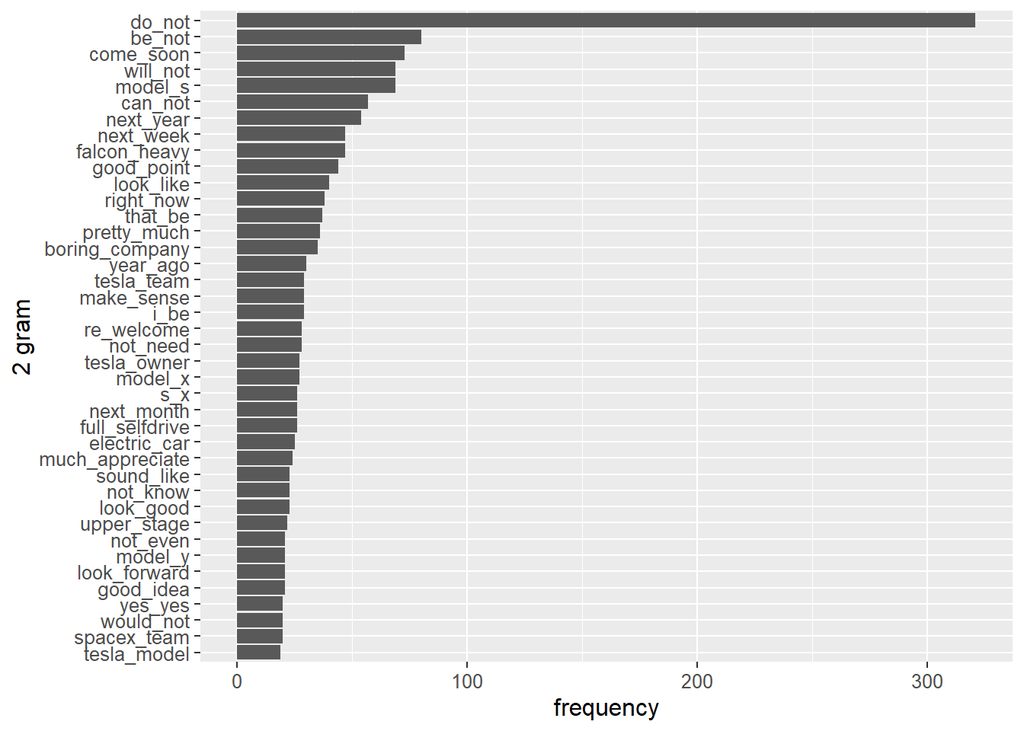

```r
# 2-word frequency (2 gram)
# create Tokens object from stemmed corpus
tokens_stemmed <- tokens(cleaned_corpus)
dfm2 = dfm(tokens_ngrams(tokens_stemmed,n=2))

dfFreq2 = textstat_frequency(dfm2)
library(ggplot2)
ggplot(dfFreq2[1:40,], aes(x=reorder(feature, frequency), y=frequency)) +
  geom_col() +
  coord_flip() +
  scale_x_discrete(name = "2 gram") +
  theme(text=element_text(size=12))
```

```r
#2-grams features to data frame
dtm2 <- convert(dfm2, to = "tm")
data_dtm2 = as.data.frame(as.matrix(dtm2))

head(data_dtm2)
```

[output not shown]

## 3 grams

This code is creating a frequency distribution of 3-grams in the text data.

The tokens_ngrams function from the quanteda package is used to create a Tokens object from the stemmed corpus with n-grams of length 3.

The dfm function is then used to create a document-feature matrix from the Tokens object.

The textstat_frequency function is used to create a frequency table of the 3-grams, which is stored in dfFreq3.

Finally, the ggplot2 package is used to create a bar plot of the top 40 most frequent 3-grams.

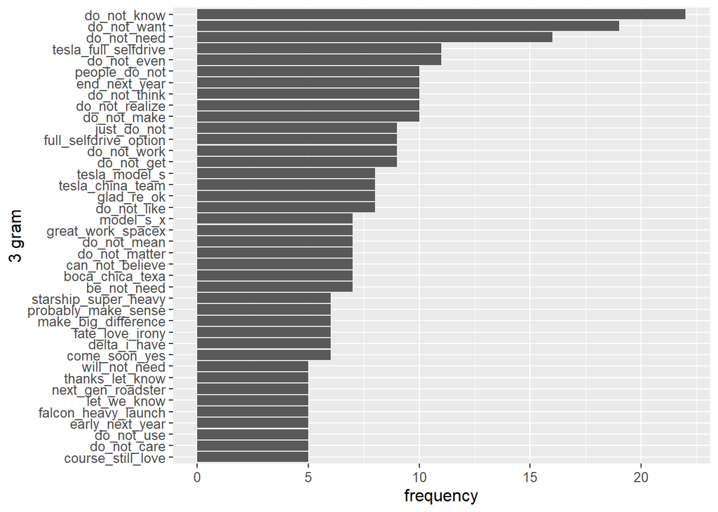

```r
# 3-word frequency (3 gram)
# create Tokens object from stemmed corpus
dfm3 = dfm(tokens_ngrams(tokens_stemmed,n=3))

dfFreq3 = textstat_frequency(dfm3)

ggplot(dfFreq3[1:40,], aes(x=reorder(feature, frequency), y=frequency)) +
  geom_col() +
  coord_flip() +
  scale_x_discrete(name = "3 gram") +
  theme(text=element_text(size=12))
```

```r
#3-grams features to data frame
dtm3 <- convert(dfm3, to = "tm")
data_dtm3 = as.data.frame(as.matrix(dtm3))
head(data_dtm3)
```

[output not shown]

```r
# Merging datasets of ngrams
tesla_sentiment = read.csv("C:/Users/Goldleverse/OneDrive/Desktop/pre_finance.csv")
ngrams_data = cbind(tesla_sentiment, data_dtm2, data_dtm3)
head(ngrams_data, 2)
```

[output not shown]

```r
merged_df = merge(ngrams_data, tsla_prices, by="date", all.y = TRUE)

# Add increase column
merged_df$increase <- c(0, ifelse(diff(merged_df$TSLA.Adjusted) > 0, 1, 0))
merged_df[,3:ncol(merged_df)-1][is.na(merged_df[, 3:ncol(merged_df)-1])] = 0
tail(merged_df, 2)
```

[output not shown]

## Fill NAs tokens and sentiment scores with 0s

```r
merged_df[,3:ncol(merged_df)-1][is.na(merged_df[, 3:ncol(merged_df)-1])] = 0
```

## Export to csv

```r
write.csv(merged_df, file="ngrams_data.csv", row.names = F)
```

# Data Modeling

This code uses fread function to import the data. Fread uses C language, which speeds up the file importation. In this case we are not using the last dataframe created during the featuring engineering part for limitations due to computational power. Indeed, the resulting dataframe would result in a matrix 250GB large.

To overcome this issue we will use the dataset originated before the exploratory analysis, which contains the date, tfidf matrix, sentiment analysis and Yahoo Finance data.

```r
library(data.table)
merged_df = fread("C:/Users/Goldleverse/OneDrive/Desktop/Datasets/tesla_sentiment.csv")

head(merged_df, 2)
```

```
##          date
## 1: 2015-01-29
## 2: 2015-01-30
##                                                                                      tweet
## 1:                                                                                       0
## 2: If you are curious about the P85D, you can schedule a test drive here: http://ts.la/dE
##    ""can"", ""test"", """", ""almost"", ""give"", ""go"", ""good"", ""launch"",
## 1:        0         0     0           0         0       0         0           0
## 2:        1         1     0           0         0       0         0           0
##    ""m"", ""much"", ""need"", ""point"", ""rocket"", ""time"", ""today"",
## 1:      0         0         0          0           0         0          0
## 2:      0         0         0          0           0         0          0
##    ""we"", ""x"", """") ""change"", ""high"", ""like"", ""still"",
## 1:       0      0     0           0         0         0          0
## 2:       0      0     0           0         0         0          0
##    ""actually"", ""come"", ""future"", ""landing"", ""maybe"", ""try"",
## 1:             0         0           0            0          0        0
## 2:             0         0           0            0          0        0
##    ""best"", ""car"", ""model"", ""s"", ""year"", ""flight"", ""next"",
## 1:         0        0          0      0         0           0         0
## 2:         0        0          0      0         0           0         0
##    ""now"", ""one"", ""work"", ""full"", ""back"", ""be"", ""build"", ""do"",
## 1:        0        0         0         0         0       0          0       0
## 2:        0        0         0         0         0       0          0       0
##    ""get"", ""mar"", ""not"", ""really"", ""see"", ""lot"", ""soon"", ""new"",
## 1:        0        0        0           0        0        0         0        0
## 2:        0        0        0           0        0        0         0        0
##    ""system"", ""company"", ""even"", ""long"", ""people"", ""think"",
## 1:           0            0         0         0           0          0
## 2:           0            0         0         0           0          0
##    ""drive"", ""hopefully"", ""tesla"", ""well"", ""just"", ""spacex"",
## 1:          0              0          0         0         0           0
## 2:          0              0          0         0         0           0
##    ""take"", ""look"", ""falcon"", ""want"", ""mean"", ""say"", ""design"",
## 1:         0         0           0         0         0        0           0
## 2:         0         0           0         0         0        0           0
##    ""power"", ""week"", ""thing"", ""many"", ""true"", ""end"", ""less"",
## 1:          0         0          0         0         0        0         0
## 2:          0         0          0         0         0        0         0
##    ""way"", ""hard"", ""big"", ""ok"", ""month"", ""day"", ""haha"", ""real"",
```

[output cut: 11 more lines]

```
##    ""heavy"", ""use"", ""super"", ""add"", ""autopilot"", ""sure"", ""make"",
## 1:          0        0          0        0              0         0         0
## 2:          0        0          0        0              0         0         0
##    ""improve"", ""sound"", ""engine"", ""earth"", ""order"", ""exactly"",
## 1:            0          0           0          0          0            0
## 2:            0          0           0          0          0            0
##    ""part"", ""pretty"", ""starship"",
## 1:         0           0             0
## 2:         0           0             0
##                                        word_scores compound   pos   neu neg
## 1:                                               0    0.000 0.000 0.000   0
## 2: {0, 0, 0, 1.3, 0, 0, 0, 0, 0, 0, 0, 0, 0, 0, 0}    0.318 0.141 0.859   0
##    but_count TSLA.Adjusted increase
## 1:         0      13.68000        0
## 2:         0      13.57333        0
```

This code converts the “date” column in merged_df from a character string in the format “YYYY-MM-DD” to a numeric value using the as.Date() and as.numeric() functions from base R.

as.Date() converts the character strings to date objects and formats them using the specified format string (“%Y-%m-%d” in this case) and assigns the results to the “date” column.

Then as.numeric() is used to convert the dates into numeric values which represent the number of days since January 1, 1970 (also known as the Unix epoch). The resulting numeric values are stored back into the “date” column of merged_df.

```r
merged_df$date <- as.Date(merged_df$date, format="%Y-%m-%d")
merged_df$date <- as.numeric(merged_df$date)
```

This code performs some data preprocessing for a time series analysis and classification task.

The next three lines select all columns except for “date”, “TSLA.Adjusted”, “increase”, “word_scores”, and “tweet” from “merged_df” and scale them using the “scale” function. This is done to standardize these variables for use in a classification model.

Finally, the “labels” variable is created by selecting the “increase” column from “merged_df”. This column contains binary values indicating whether the stock price increased (1) or decreased (0) on a given day. This will be the target variable in the classification model.

```r
time_series = merged_df %>% select(TSLA.Adjusted)
time_series = scale(time_series)

nlp_data = merged_df %>% select(-date, -TSLA.Adjusted, -increase, -word_scores, -tweet)
nlp_data = scale(nlp_data)

labels = merged_df$increase
```

```r
ncol(time_series)
```

```
## [1] 1
```

```r
nrow(time_series)
```

```
## [1] 1374
```

```r
ncol(nlp_data)
```

```
## [1] 125
```

```r
nrow(nlp_data)
```

```
## [1] 1374
```

This code conver the time series dataframe into a matrix, which is the required input format for the LSTM model

```r
time_series = as.matrix(time_series)
```

## Model 1 (Simple Version)

This code trains a deep learning model using Keras to make predictions based on two types of data: time series and NLP (natural language processing) data. The model architecture includes two LSTM layers and a dense layer, and it is trained using binary cross-entropy loss and the Adam optimizer. The model is also evaluated using accuracy as a metric.

The steps in the model are:

```r
max_time_steps <- nrow(time_series)
num_features <- ncol(time_series)
max_words <- nrow(nlp_data)
embedding_dim <- ncol(nlp_data)
lstm_units <- 32
dense_units <- 64

# Reshape time series data to match the input shape of the model
time_series <- array(data = time_series, dim = c(nrow(time_series), max_time_steps, num_features))

# Reshape NLP data to match the input shape of the model
nlp_data <- array(data = nlp_data, dim = c(nrow(nlp_data), max_words, embedding_dim))

# Define input shapes for time series and NLP data
ts_input_shape <- c(max_time_steps, num_features)
nlp_input_shape <- c(max_words, embedding_dim)

# Define LSTM-based model architecture
ts_input <- layer_input(shape = ts_input_shape, name = "ts_input")
ts_lstm <- layer_lstm(units = lstm_units, return_sequences = TRUE)(ts_input)
ts_output <- layer_global_max_pooling_1d()(ts_lstm)

nlp_input <- layer_input(shape = nlp_input_shape, name = "nlp_input")
nlp_lstm <- layer_lstm(units = lstm_units)(nlp_input)
nlp_output <- layer_dense(units = dense_units, activation = "relu")(nlp_lstm)

combined <- layer_concatenate(inputs = list(ts_output, nlp_output), name = "combined")
output <- layer_dense(units = 1, activation = "sigmoid")(combined)

model <- keras_model(inputs = list(ts_input, nlp_input), outputs = output)

# Compile the model
model %>% compile(
  loss = "binary_crossentropy",
  optimizer = optimizer_adam(),
  metrics = c("accuracy")
)

# Define a callback to save the model with the best accuracy
best_model_callback <- callback_model_checkpoint(
  filepath = "best_model.h5",
  save_best_only = TRUE,
  monitor = "val_accuracy",
  mode = "max"
)

# Train the model with early stopping and the best model callback
history <- model %>% fit(
  x = list(time_series, nlp_data),
  y = labels,
  epochs = 2000,
  batch_size = 32,
  validation_split = 0.2,
  verbose = 2,
  callbacks = list(
    callback_early_stopping(patience = 100),
    best_model_callback
  )
)

# Evaluate the model
scores <- model %>% evaluate(
  x = list(time_series, nlp_data),
  y = labels,
  batch_size = 32
)

# Print the evaluation metrics
cat("Test loss:", scores[[1]], "\n")
```

```
## Test loss: 0.9218721
```

```r
cat("Test accuracy:", scores[[2]], "\n")
```

```
## Test accuracy: 0.7489083
```